# Project5_Premani

## Background & Context

The Thera bank recently saw a steep decline in the number of users of their credit card, credit cards are a good source of income for banks because of different kinds of fees charged by the banks like annual fees, balance transfer fees, and cash advance fees, late payment fees, foreign transaction fees, and others. Some fees are charged to every user irrespective of usage, while others are charged under specified circumstances.

Customers’ leaving credit cards services would lead bank to loss, so the bank wants to analyze the data of customers and identify the customers who will leave their credit card services and reason for same – so that bank could improve upon those areas

You as a Data scientist at Thera bank need to come up with a classification model that will help the bank improve its services so that customers do not renounce their credit cards

You need to identify the best possible model that will give the required performance

## Objective

Explore and visualize the dataset. Build a classification model to predict if the customer is going to churn or not Optimize the model using appropriate techniques Generate a set of insights and recommendations that will help the bank

## Data Dictionary:

CLIENTNUM: Client number. Unique identifier for the customer holding the account

Attrition_Flag: Internal event (customer activity) variable - if the account is closed then "Attrited Customer" else "Existing Customer"

Customer_Age: Age in Years

Gender: Gender of the account holder

Dependent_count: Number of dependents

Education_Level: Educational Qualification of the account holder - Graduate, High School, Unknown, Uneducated, College(refers to a college student), Post-Graduate, Doctorate.

Marital_Status: Marital Status of the account holder

Income_Category: Annual Income Category of the account holder

Card_Category: Type of Card

Months_on_book: Period of relationship with the bank

Total_Relationship_Count: Total no. of products held by the customer

Months_Inactive_12_mon: No. of months inactive in the last 12 months

Contacts_Count_12_mon: No. of Contacts between the customer and bank in the last 12 months

Credit_Limit: Credit Limit on the Credit Card

Total_Revolving_Bal: The balance that carries over from one month to the next is the revolving balance

Avg_Open_To_Buy: Open to Buy refers to the amount left on the credit card to use (Average of last 12 months)

Total_Trans_Amt: Total Transaction Amount (Last 12 months)

Total_Trans_Ct: Total Transaction Count (Last 12 months)

Total_Ct_Chng_Q4_Q1: Ratio of the total transaction count in 4th quarter and the total transaction count in 1st quarter

Total_Amt_Chng_Q4_Q1: Ratio of the total transaction amount in 4th quarter and the total transaction amount in 1st quarter

Avg_Utilization_Ratio: Represents how much of the available credit the customer spent

```python
# import the basics
import numpy as np
import pandas as pd
import matplotlib.pyplot as plt
import seaborn as sns

# To be used for missing value imputation
from sklearn.impute import SimpleImputer

# import ML tools
from sklearn.linear_model import LogisticRegression
from sklearn.tree import DecisionTreeClassifier

from sklearn.ensemble import AdaBoostClassifier, BaggingClassifier, GradientBoostingClassifier, \
RandomForestClassifier, StackingClassifier

from xgboost import XGBClassifier

from sklearn.model_selection import GridSearchCV, RandomizedSearchCV, \
StratifiedKFold, train_test_split, cross_val_score

from sklearn import metrics

from sklearn.preprocessing import OneHotEncoder, StandardScaler, MinMaxScaler

# pipeline creation and personalization
from sklearn.pipeline import make_pipeline, Pipeline
from sklearn.compose import ColumnTransformer
from sklearn.preprocessing import FunctionTransformer

# To undersample and oversample the data
from imblearn.over_sampling import SMOTE
from imblearn.under_sampling import RandomUnderSampler

# warnings
import warnings
warnings.filterwarnings("ignore")

# max columns limit removal
pd.set_option("display.max_columns", None)
```

## Data Overview

```python
df = pd.read_csv('BankChurners.csv')
df.shape
```

```
(10127, 21)
```

```python
df.head()
```

|  | CLIENTNUM | Attrition_Flag | Customer_Age | Gender | Dependent_count | Education_Level | Marital_Status | Income_Category | Card_Category | Months_on_book | Total_Relationship_Count | Months_Inactive_12_mon | Contacts_Count_12_mon | Credit_Limit | Total_Revolving_Bal | Avg_Open_To_Buy | Total_Amt_Chng_Q4_Q1 | Total_Trans_Amt | Total_Trans_Ct | Total_Ct_Chng_Q4_Q1 | Avg_Utilization_Ratio |
| --- | --- | --- | --- | --- | --- | --- | --- | --- | --- | --- | --- | --- | --- | --- | --- | --- | --- | --- | --- | --- | --- |
| 0 | 768805383 | Existing Customer | 45 | M | 3 | High School | Married | $60K - $80K | Blue | 39 | 5 | 1 | 3 | 12691.0 | 777 | 11914.0 | 1.335 | 1144 | 42 | 1.625 | 0.061 |
| 1 | 818770008 | Existing Customer | 49 | F | 5 | Graduate | Single | Less than $40K | Blue | 44 | 6 | 1 | 2 | 8256.0 | 864 | 7392.0 | 1.541 | 1291 | 33 | 3.714 | 0.105 |
| 2 | 713982108 | Existing Customer | 51 | M | 3 | Graduate | Married | $80K - $120K | Blue | 36 | 4 | 1 | 0 | 3418.0 | 0 | 3418.0 | 2.594 | 1887 | 20 | 2.333 | 0.000 |
| 3 | 769911858 | Existing Customer | 40 | F | 4 | High School | NaN | Less than $40K | Blue | 34 | 3 | 4 | 1 | 3313.0 | 2517 | 796.0 | 1.405 | 1171 | 20 | 2.333 | 0.760 |
| 4 | 709106358 | Existing Customer | 40 | M | 3 | Uneducated | Married | $60K - $80K | Blue | 21 | 5 | 1 | 0 | 4716.0 | 0 | 4716.0 | 2.175 | 816 | 28 | 2.500 | 0.000 |

```python
df.info()
```

```
<class 'pandas.core.frame.DataFrame'>
RangeIndex: 10127 entries, 0 to 10126
Data columns (total 21 columns):
 #   Column                    Non-Null Count  Dtype
---  ------                    --------------  -----
 0   CLIENTNUM                 10127 non-null  int64
 1   Attrition_Flag            10127 non-null  object
 2   Customer_Age              10127 non-null  int64
 3   Gender                    10127 non-null  object
 4   Dependent_count           10127 non-null  int64
 5   Education_Level           8608 non-null   object
 6   Marital_Status            9378 non-null   object
 7   Income_Category           10127 non-null  object
 8   Card_Category             10127 non-null  object
 9   Months_on_book            10127 non-null  int64
 10  Total_Relationship_Count  10127 non-null  int64
 11  Months_Inactive_12_mon    10127 non-null  int64
 12  Contacts_Count_12_mon     10127 non-null  int64
 13  Credit_Limit              10127 non-null  float64
 14  Total_Revolving_Bal       10127 non-null  int64
 15  Avg_Open_To_Buy           10127 non-null  float64
 16  Total_Amt_Chng_Q4_Q1      10127 non-null  float64
 17  Total_Trans_Amt           10127 non-null  int64
 18  Total_Trans_Ct            10127 non-null  int64
 19  Total_Ct_Chng_Q4_Q1       10127 non-null  float64
 20  Avg_Utilization_Ratio     10127 non-null  float64
dtypes: float64(5), int64(10), object(6)
memory usage: 1.6+ MB
```

Data has 10127 rows and 21 columns. Out of all columns, only two have null values: Education_Level and Marital_Status.

Let's see if there are any duplicated values.

```python
df.duplicated().sum()
```

```
0
```

```python
df.describe().apply(np.round).T
```

|  | count | mean | std | min | 25% | 50% | 75% | max |
| --- | --- | --- | --- | --- | --- | --- | --- | --- |
| CLIENTNUM | 10127.0 | 739177606.0 | 36903783.0 | 708082083.0 | 713036770.0 | 717926358.0 | 773143533.0 | 828343083.0 |
| Customer_Age | 10127.0 | 46.0 | 8.0 | 26.0 | 41.0 | 46.0 | 52.0 | 73.0 |
| Dependent_count | 10127.0 | 2.0 | 1.0 | 0.0 | 1.0 | 2.0 | 3.0 | 5.0 |
| Months_on_book | 10127.0 | 36.0 | 8.0 | 13.0 | 31.0 | 36.0 | 40.0 | 56.0 |
| Total_Relationship_Count | 10127.0 | 4.0 | 2.0 | 1.0 | 3.0 | 4.0 | 5.0 | 6.0 |
| Months_Inactive_12_mon | 10127.0 | 2.0 | 1.0 | 0.0 | 2.0 | 2.0 | 3.0 | 6.0 |
| Contacts_Count_12_mon | 10127.0 | 2.0 | 1.0 | 0.0 | 2.0 | 2.0 | 3.0 | 6.0 |
| Credit_Limit | 10127.0 | 8632.0 | 9089.0 | 1438.0 | 2555.0 | 4549.0 | 11068.0 | 34516.0 |
| Total_Revolving_Bal | 10127.0 | 1163.0 | 815.0 | 0.0 | 359.0 | 1276.0 | 1784.0 | 2517.0 |
| Avg_Open_To_Buy | 10127.0 | 7469.0 | 9091.0 | 3.0 | 1324.0 | 3474.0 | 9859.0 | 34516.0 |
| Total_Amt_Chng_Q4_Q1 | 10127.0 | 1.0 | 0.0 | 0.0 | 1.0 | 1.0 | 1.0 | 3.0 |
| Total_Trans_Amt | 10127.0 | 4404.0 | 3397.0 | 510.0 | 2156.0 | 3899.0 | 4741.0 | 18484.0 |
| Total_Trans_Ct | 10127.0 | 65.0 | 23.0 | 10.0 | 45.0 | 67.0 | 81.0 | 139.0 |
| Total_Ct_Chng_Q4_Q1 | 10127.0 | 1.0 | 0.0 | 0.0 | 1.0 | 1.0 | 1.0 | 4.0 |
| Avg_Utilization_Ratio | 10127.0 | 0.0 | 0.0 | 0.0 | 0.0 | 0.0 | 1.0 | 1.0 |

```python
# get exact values so we dont miss information from rounding off
df[['Total_Amt_Chng_Q4_Q1','Total_Ct_Chng_Q4_Q1','Avg_Utilization_Ratio']].describe().T
```

|  | count | mean | std | min | 25% | 50% | 75% | max |
| --- | --- | --- | --- | --- | --- | --- | --- | --- |
| Total_Amt_Chng_Q4_Q1 | 10127.0 | 0.759941 | 0.219207 | 0.0 | 0.631 | 0.736 | 0.859 | 3.397 |
| Total_Ct_Chng_Q4_Q1 | 10127.0 | 0.712222 | 0.238086 | 0.0 | 0.582 | 0.702 | 0.818 | 3.714 |
| Avg_Utilization_Ratio | 10127.0 | 0.274894 | 0.275691 | 0.0 | 0.023 | 0.176 | 0.503 | 0.999 |

Let's remove CLIENTNUM column since we don't need it.

```python
df.drop(columns='CLIENTNUM',axis=1,inplace=True)
df.head()
```

|  | Attrition_Flag | Customer_Age | Gender | Dependent_count | Education_Level | Marital_Status | Income_Category | Card_Category | Months_on_book | Total_Relationship_Count | Months_Inactive_12_mon | Contacts_Count_12_mon | Credit_Limit | Total_Revolving_Bal | Avg_Open_To_Buy | Total_Amt_Chng_Q4_Q1 | Total_Trans_Amt | Total_Trans_Ct | Total_Ct_Chng_Q4_Q1 | Avg_Utilization_Ratio |
| --- | --- | --- | --- | --- | --- | --- | --- | --- | --- | --- | --- | --- | --- | --- | --- | --- | --- | --- | --- | --- |
| 0 | Existing Customer | 45 | M | 3 | High School | Married | $60K - $80K | Blue | 39 | 5 | 1 | 3 | 12691.0 | 777 | 11914.0 | 1.335 | 1144 | 42 | 1.625 | 0.061 |
| 1 | Existing Customer | 49 | F | 5 | Graduate | Single | Less than $40K | Blue | 44 | 6 | 1 | 2 | 8256.0 | 864 | 7392.0 | 1.541 | 1291 | 33 | 3.714 | 0.105 |
| 2 | Existing Customer | 51 | M | 3 | Graduate | Married | $80K - $120K | Blue | 36 | 4 | 1 | 0 | 3418.0 | 0 | 3418.0 | 2.594 | 1887 | 20 | 2.333 | 0.000 |
| 3 | Existing Customer | 40 | F | 4 | High School | NaN | Less than $40K | Blue | 34 | 3 | 4 | 1 | 3313.0 | 2517 | 796.0 | 1.405 | 1171 | 20 | 2.333 | 0.760 |
| 4 | Existing Customer | 40 | M | 3 | Uneducated | Married | $60K - $80K | Blue | 21 | 5 | 1 | 0 | 4716.0 | 0 | 4716.0 | 2.175 | 816 | 28 | 2.500 | 0.000 |

```python
df.info()
```

```
<class 'pandas.core.frame.DataFrame'>
RangeIndex: 10127 entries, 0 to 10126
Data columns (total 20 columns):
 #   Column                    Non-Null Count  Dtype
---  ------                    --------------  -----
 0   Attrition_Flag            10127 non-null  object
 1   Customer_Age              10127 non-null  int64
 2   Gender                    10127 non-null  object
 3   Dependent_count           10127 non-null  int64
 4   Education_Level           8608 non-null   object
 5   Marital_Status            9378 non-null   object
 6   Income_Category           10127 non-null  object
 7   Card_Category             10127 non-null  object
 8   Months_on_book            10127 non-null  int64
 9   Total_Relationship_Count  10127 non-null  int64
 10  Months_Inactive_12_mon    10127 non-null  int64
 11  Contacts_Count_12_mon     10127 non-null  int64
 12  Credit_Limit              10127 non-null  float64
 13  Total_Revolving_Bal       10127 non-null  int64
 14  Avg_Open_To_Buy           10127 non-null  float64
 15  Total_Amt_Chng_Q4_Q1      10127 non-null  float64
 16  Total_Trans_Amt           10127 non-null  int64
 17  Total_Trans_Ct            10127 non-null  int64
 18  Total_Ct_Chng_Q4_Q1       10127 non-null  float64
 19  Avg_Utilization_Ratio     10127 non-null  float64
dtypes: float64(5), int64(9), object(6)
memory usage: 1.5+ MB
```

## Exploratory Data Analysis

```python
categorical_cols = df.columns[df.dtypes == 'object']
print(categorical_cols)
```

```
Index(['Attrition_Flag', 'Gender', 'Education_Level', 'Marital_Status',
       'Income_Category', 'Card_Category'],
      dtype='object')
```

```python
numerical_cols = df.columns[df.dtypes != 'object']
print(numerical_cols)
```

```
Index(['Customer_Age', 'Dependent_count', 'Months_on_book',
       'Total_Relationship_Count', 'Months_Inactive_12_mon',
       'Contacts_Count_12_mon', 'Credit_Limit', 'Total_Revolving_Bal',
       'Avg_Open_To_Buy', 'Total_Amt_Chng_Q4_Q1', 'Total_Trans_Amt',
       'Total_Trans_Ct', 'Total_Ct_Chng_Q4_Q1', 'Avg_Utilization_Ratio'],
      dtype='object')
```

### Univariate EDA - Numerical Columns

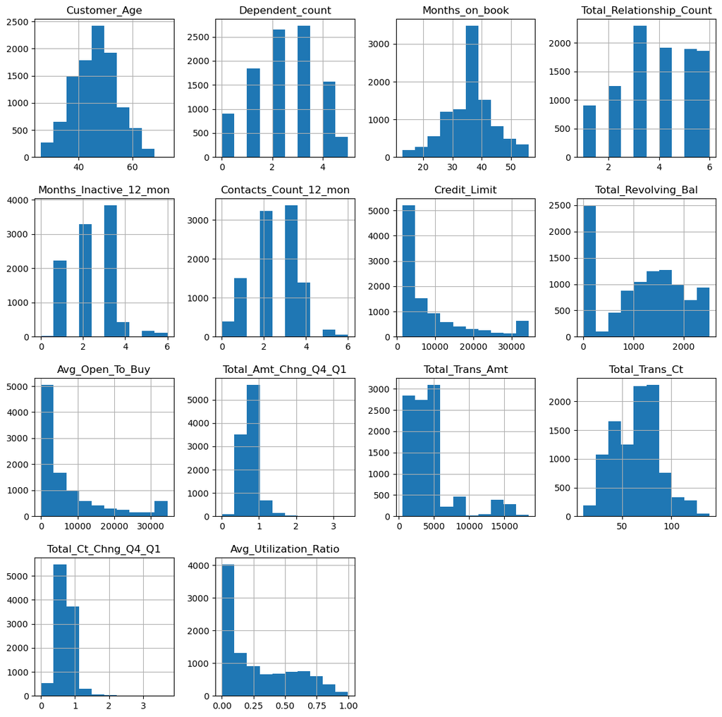

```python
df[numerical_cols].hist(figsize=(14, 14))
plt.show()
```

### Outlier Inspection

```python
# credit limit
df.loc[df.Credit_Limit>33000,:].sample(n=10)
```

|  | Attrition_Flag | Customer_Age | Gender | Dependent_count | Education_Level | Marital_Status | Income_Category | Card_Category | Months_on_book | Total_Relationship_Count | Months_Inactive_12_mon | Contacts_Count_12_mon | Credit_Limit | Total_Revolving_Bal | Avg_Open_To_Buy | Total_Amt_Chng_Q4_Q1 | Total_Trans_Amt | Total_Trans_Ct | Total_Ct_Chng_Q4_Q1 | Avg_Utilization_Ratio |
| --- | --- | --- | --- | --- | --- | --- | --- | --- | --- | --- | --- | --- | --- | --- | --- | --- | --- | --- | --- | --- |
| 9460 | Existing Customer | 43 | M | 2 | Graduate | Single | $80K - $120K | Blue | 36 | 2 | 2 | 1 | 34427.0 | 1613 | 32814.0 | 0.704 | 13545 | 112 | 0.672 | 0.047 |
| 8892 | Existing Customer | 43 | M | 4 | Uneducated | Single | $120K + | Blue | 36 | 1 | 1 | 3 | 34516.0 | 1742 | 32774.0 | 0.661 | 7360 | 82 | 0.745 | 0.050 |
| 1026 | Existing Customer | 54 | M | 3 | Graduate | Married | $120K + | Blue | 46 | 3 | 1 | 3 | 34516.0 | 854 | 33662.0 | 0.928 | 1999 | 54 | 0.800 | 0.025 |
| 731 | Existing Customer | 52 | M | 1 | Doctorate | Married | $120K + | Blue | 41 | 4 | 2 | 2 | 33864.0 | 989 | 32875.0 | 1.219 | 1751 | 48 | 0.920 | 0.029 |
| 7032 | Existing Customer | 45 | M | 3 | Graduate | Single | $60K - $80K | Silver | 34 | 5 | 1 | 1 | 34516.0 | 1664 | 32852.0 | 0.730 | 4912 | 80 | 0.739 | 0.048 |
| 9682 | Existing Customer | 49 | M | 4 | Post-Graduate | Single | $120K + | Silver | 38 | 3 | 3 | 1 | 34516.0 | 1562 | 32954.0 | 0.618 | 14212 | 100 | 0.667 | 0.045 |
| 2416 | Attrited Customer | 55 | M | 3 | Uneducated | Divorced | $80K - $120K | Blue | 41 | 1 | 3 | 4 | 34516.0 | 2408 | 32108.0 | 0.796 | 1187 | 40 | 0.600 | 0.070 |
| 2833 | Existing Customer | 49 | M | 4 | Graduate | Married | $80K - $120K | Blue | 39 | 5 | 1 | 1 | 34516.0 | 543 | 33973.0 | 0.745 | 3951 | 76 | 0.900 | 0.016 |
| 3685 | Existing Customer | 52 | M | 2 | High School | Single | $120K + | Blue | 43 | 3 | 2 | 3 | 34516.0 | 761 | 33755.0 | 0.916 | 4313 | 82 | 0.547 | 0.022 |
| 1506 | Existing Customer | 34 | M | 4 | Uneducated | Single | $120K + | Blue | 36 | 6 | 3 | 2 | 34516.0 | 2517 | 31999.0 | 0.975 | 1969 | 46 | 1.300 | 0.073 |

```python
# low income
df.loc[df.Income_Category=='Less than $40K',:].sample(n=10)
```

|  | Attrition_Flag | Customer_Age | Gender | Dependent_count | Education_Level | Marital_Status | Income_Category | Card_Category | Months_on_book | Total_Relationship_Count | Months_Inactive_12_mon | Contacts_Count_12_mon | Credit_Limit | Total_Revolving_Bal | Avg_Open_To_Buy | Total_Amt_Chng_Q4_Q1 | Total_Trans_Amt | Total_Trans_Ct | Total_Ct_Chng_Q4_Q1 | Avg_Utilization_Ratio |
| --- | --- | --- | --- | --- | --- | --- | --- | --- | --- | --- | --- | --- | --- | --- | --- | --- | --- | --- | --- | --- |
| 1252 | Existing Customer | 37 | F | 2 | Uneducated | Married | Less than $40K | Blue | 28 | 5 | 2 | 4 | 6660.0 | 1362 | 5298.0 | 1.360 | 2660 | 51 | 0.759 | 0.205 |
| 6073 | Existing Customer | 37 | F | 2 | Post-Graduate | Married | Less than $40K | Blue | 36 | 6 | 2 | 3 | 2310.0 | 1513 | 797.0 | 0.682 | 4191 | 77 | 0.833 | 0.655 |
| 7738 | Attrited Customer | 54 | F | 1 | Graduate | Single | Less than $40K | Blue | 34 | 5 | 2 | 2 | 2939.0 | 2152 | 787.0 | 0.555 | 2476 | 42 | 0.355 | 0.732 |
| 1312 | Existing Customer | 44 | F | 2 | NaN | NaN | Less than $40K | Blue | 32 | 5 | 1 | 3 | 4852.0 | 1777 | 3075.0 | 0.667 | 1775 | 55 | 1.037 | 0.366 |
| 5358 | Existing Customer | 41 | F | 4 | Graduate | Single | Less than $40K | Blue | 35 | 3 | 1 | 4 | 2138.0 | 1283 | 855.0 | 0.645 | 4785 | 85 | 0.518 | 0.600 |
| 1875 | Existing Customer | 43 | F | 2 | College | Married | Less than $40K | Blue | 36 | 6 | 2 | 4 | 6979.0 | 898 | 6081.0 | 0.565 | 1665 | 44 | 0.375 | 0.129 |
| 582 | Existing Customer | 53 | F | 4 | High School | Married | Less than $40K | Blue | 36 | 6 | 1 | 3 | 2974.0 | 1170 | 1804.0 | 1.297 | 1785 | 45 | 1.143 | 0.393 |
| 8008 | Attrited Customer | 53 | F | 3 | Graduate | Single | Less than $40K | Blue | 34 | 5 | 3 | 5 | 1438.3 | 1030 | 408.3 | 0.609 | 1985 | 38 | 0.407 | 0.716 |
| 50 | Existing Customer | 52 | F | 3 | NaN | Married | Less than $40K | Blue | 41 | 6 | 3 | 2 | 2622.0 | 1549 | 1073.0 | 1.321 | 1878 | 30 | 1.143 | 0.591 |
| 1781 | Existing Customer | 29 | F | 0 | Uneducated | Divorced | Less than $40K | Blue | 19 | 5 | 4 | 4 | 2926.0 | 0 | 2926.0 | 0.840 | 2775 | 74 | 1.114 | 0.000 |

```python
# check for errors: whether any data points have total revolving balance more than their credit limit
df.loc[df.Total_Revolving_Bal>df.Credit_Limit,:]
```

|  | Attrition_Flag | Customer_Age | Gender | Dependent_count | Education_Level | Marital_Status | Income_Category | Card_Category | Months_on_book | Total_Relationship_Count | Months_Inactive_12_mon | Contacts_Count_12_mon | Credit_Limit | Total_Revolving_Bal | Avg_Open_To_Buy | Total_Amt_Chng_Q4_Q1 | Total_Trans_Amt | Total_Trans_Ct | Total_Ct_Chng_Q4_Q1 | Avg_Utilization_Ratio |
| --- | --- | --- | --- | --- | --- | --- | --- | --- | --- | --- | --- | --- | --- | --- | --- | --- | --- | --- | --- | --- |

Comments for outliers:

- There are no outliers that are concerning. Hence, we will have no outlier treatment for this data.

### Univariate EDA - Categorical Columns

```python
for col in categorical_cols:
    print(df[col].value_counts())
    print('*' * 40)
```

```
Existing Customer    8500
Attrited Customer    1627
Name: Attrition_Flag, dtype: int64
F    5358
M    4769
Name: Gender, dtype: int64
Graduate         3128
High School      2013
Uneducated       1487
College          1013
Post-Graduate     516
Doctorate         451
Name: Education_Level, dtype: int64
Married     4687
Single      3943
Divorced     748
Name: Marital_Status, dtype: int64
Less than $40K    3561
$40K - $60K       1790
$80K - $120K      1535
$60K - $80K       1402
abc               1112
$120K +            727
Name: Income_Category, dtype: int64
Blue        9436
Silver       555
Gold         116
Platinum      20
Name: Card_Category, dtype: int64
```

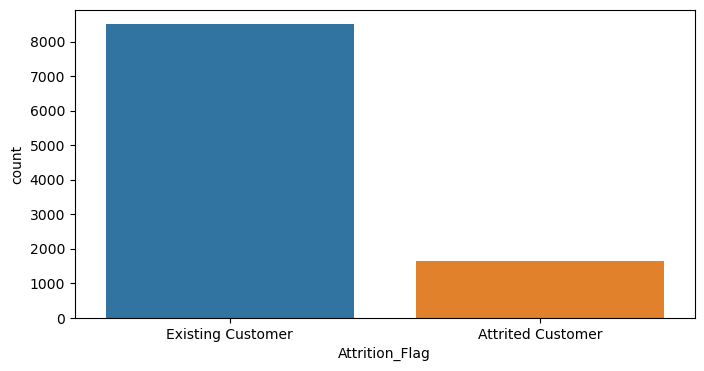

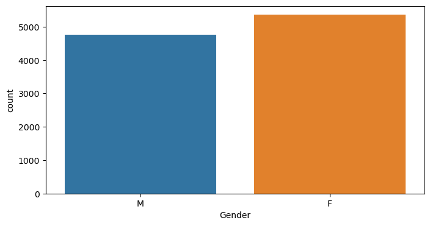

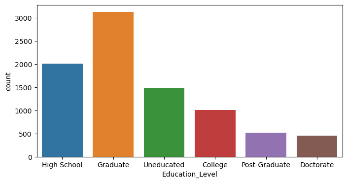

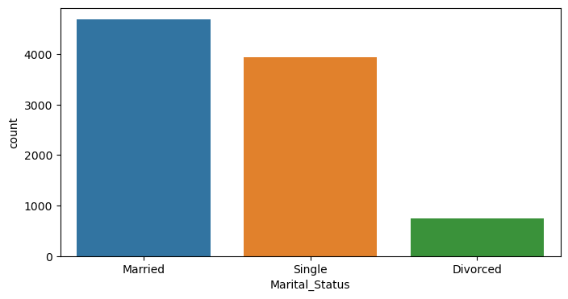

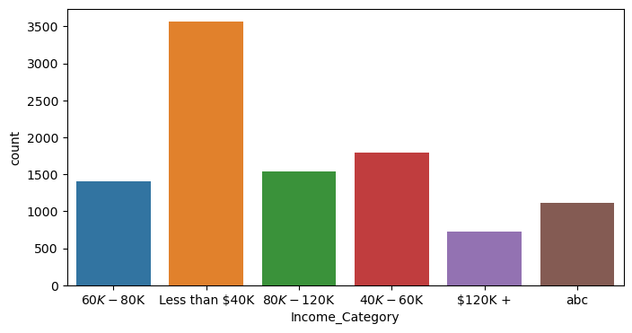

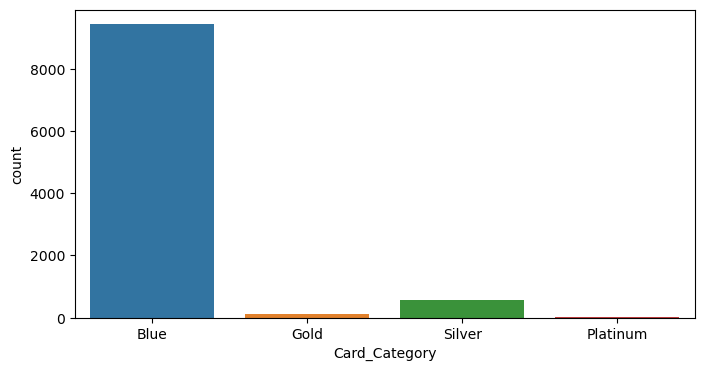

```python
for col in categorical_cols:
    plt.figure(figsize=[8,4])
    sns.countplot(data=df, x=col)
    plt.show()
```

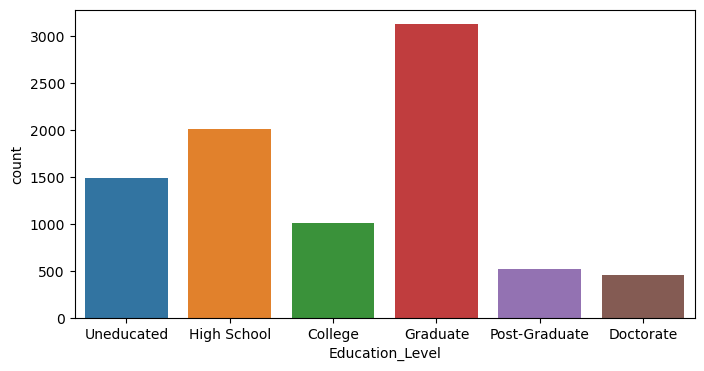

```python
# display education level histogram in ordered fashion
df_test = df.copy()
df_test['Education_Level'] = pd.Categorical(df_test['Education_Level'],
                                   categories=['Uneducated', 'High School', 'College', 'Graduate','Post-Graduate', 'Doctorate'],
                                   ordered=True)
plt.figure(figsize=[8,4])
sns.countplot(data=df_test, x='Education_Level')
plt.show()
```

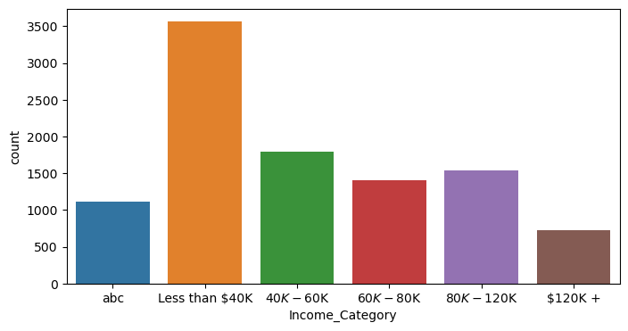

```python
# display income category histogram in ordered fashion
df_test['Income_Category'] = pd.Categorical(df_test['Income_Category'],
                                   categories=['abc','Less than $40K', '$40K - $60K', '$60K - $80K', '$80K - $120K','$120K +'],
                                   ordered=True)
plt.figure(figsize=[8,4])
sns.countplot(data=df_test, x='Income_Category')
plt.show()
```

'abc' category in income level does not make sense. We will impute mode for this column since data is categorical.

```python
df.Income_Category.value_counts()
```

```
Less than $40K    3561
$40K - $60K       1790
$80K - $120K      1535
$60K - $80K       1402
abc               1112
$120K +            727
Name: Income_Category, dtype: int64
```

```python
df2 = df.copy()
df2.loc[df2.Income_Category=='abc','Income_Category'] = df2.Income_Category.mode()[0]
df2.loc[df2.Income_Category=='abc',:]
```

|  | Attrition_Flag | Customer_Age | Gender | Dependent_count | Education_Level | Marital_Status | Income_Category | Card_Category | Months_on_book | Total_Relationship_Count | Months_Inactive_12_mon | Contacts_Count_12_mon | Credit_Limit | Total_Revolving_Bal | Avg_Open_To_Buy | Total_Amt_Chng_Q4_Q1 | Total_Trans_Amt | Total_Trans_Ct | Total_Ct_Chng_Q4_Q1 | Avg_Utilization_Ratio |
| --- | --- | --- | --- | --- | --- | --- | --- | --- | --- | --- | --- | --- | --- | --- | --- | --- | --- | --- | --- | --- |

```python
df2.Income_Category.value_counts()
```

```
Less than $40K    4673
$40K - $60K       1790
$80K - $120K      1535
$60K - $80K       1402
$120K +            727
Name: Income_Category, dtype: int64
```

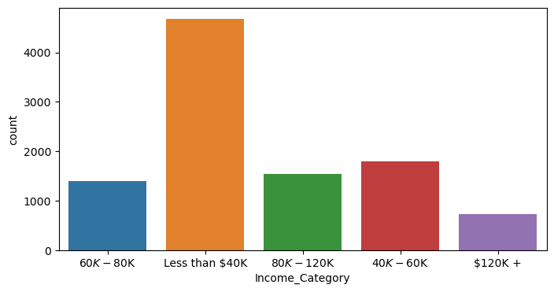

```python
# plotting Income category again
plt.figure(figsize=[8,4])
sns.countplot(data=df2, x='Income_Category')
plt.show()
```

Observations:

### Bivariate EDA - Numerical Columns

Let's check the importance of numerical variables.

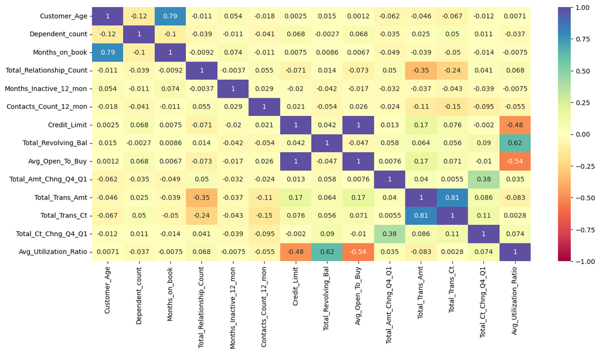

```python
plt.figure(figsize=(15,7))
sns.heatmap(df2.corr(), annot=True, vmin=-1, vmax=1, cmap='Spectral');
plt.show()
```

Observations:

- Months on book has a high positive correlation with the customer's age, which makes sense since the older you are, the more likely that you have used a credit card. This also indicates that most customers have been loyal to this company and its product(s).
- Total transaction amount and count have a slight negative correlation with total relationship count.
- Avg utilization ratio has a negative correlation with credit limit, indicating that the higher your credit limit, the lower you tend to spend, or perhaps you spend lower in proportion to your credit limit.
- Avg utilization ratio has a positive correlation with total revolving balance, which is interesting. The higher proporrtion of credit a customer has spent, there is more likelihood of a non zero balance rolling over to the next month AND more chances that the mentioned balance being roller over is higher.
- Avg utilization ratio has a negative correlation with average open to buy, which is trivial. The more proportion of credit a customer has spent, the less credit they have remaining.

Let's check the relationship between Attrition_Flag and numerical independent variables.

```python
df2.groupby(["Attrition_Flag"])[numerical_cols].mean()
```

| Attrition_Flag | Customer_Age | Dependent_count | Months_on_book | Total_Relationship_Count | Months_Inactive_12_mon | Contacts_Count_12_mon | Credit_Limit | Total_Revolving_Bal | Avg_Open_To_Buy | Total_Amt_Chng_Q4_Q1 | Total_Trans_Amt | Total_Trans_Ct | Total_Ct_Chng_Q4_Q1 | Avg_Utilization_Ratio |
| --- | --- | --- | --- | --- | --- | --- | --- | --- | --- | --- | --- | --- | --- | --- |
| Attrited Customer | 46.659496 | 2.402581 | 36.178242 | 3.279656 | 2.693301 | 2.972342 | 8136.039459 | 672.822987 | 7463.216472 | 0.694277 | 3095.025814 | 44.933620 | 0.554386 | 0.162475 |
| Existing Customer | 46.262118 | 2.335412 | 35.880588 | 3.914588 | 2.273765 | 2.356353 | 8726.877518 | 1256.604118 | 7470.273400 | 0.772510 | 4654.655882 | 68.672588 | 0.742434 | 0.296412 |

Let's check the relationship between Attrition_Flag and categorical independent variables.

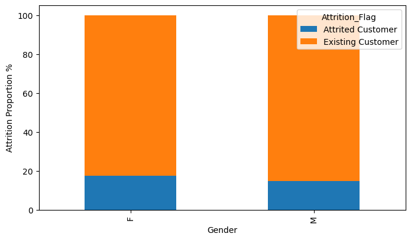

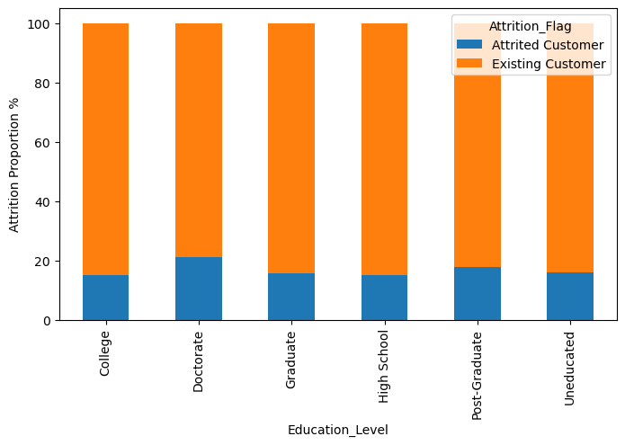

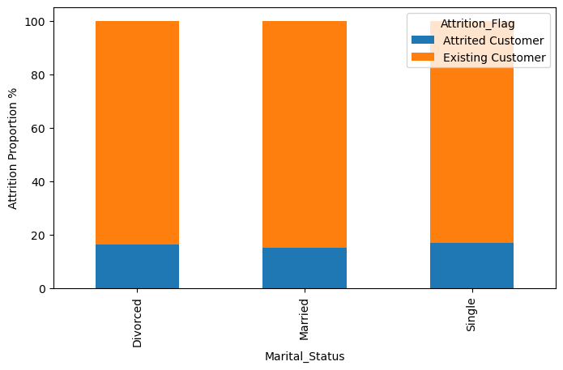

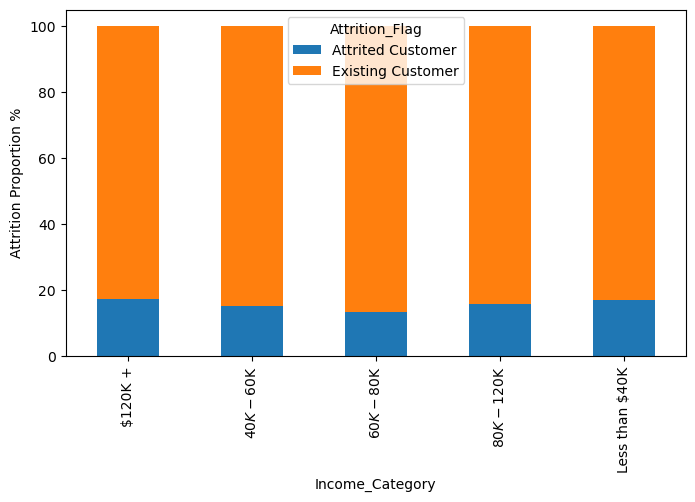

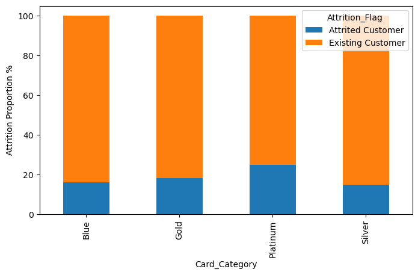

```python
for col in categorical_cols:
    if col != "Attrition_Flag":
        (pd.crosstab(df2[col], df2["Attrition_Flag"], normalize="index") * 100).plot(
            kind="bar", figsize=(8, 4.5), stacked=True
        )
        plt.ylabel("Attrition Proportion %")
```

Observations:

- Females, Doctorates, income category of less than \$40k and more than \$120k, and Platinum card holders are slightly more likely to be attrited.
- More existing customers are in the \$60k-\$80k income bracket, are Male, and have High School or Graduate education level.
- Overall, all trends seem to be weak - we don't see many strong signals.

## Model Building

```python
# creating copy of model for model building purposes
df3 = df2.copy()
```

```python
# Preparing categorical columns for model building
df3.loc[df3.Attrition_Flag=='Existing Customer','Attrition_Flag'] = 1
df3.loc[df3.Attrition_Flag=='Attrited Customer','Attrition_Flag'] = 0
df3['Attrition_Flag'] = pd.to_numeric(df3['Attrition_Flag'])

df3.head()
```

|  | Attrition_Flag | Customer_Age | Gender | Dependent_count | Education_Level | Marital_Status | Income_Category | Card_Category | Months_on_book | Total_Relationship_Count | Months_Inactive_12_mon | Contacts_Count_12_mon | Credit_Limit | Total_Revolving_Bal | Avg_Open_To_Buy | Total_Amt_Chng_Q4_Q1 | Total_Trans_Amt | Total_Trans_Ct | Total_Ct_Chng_Q4_Q1 | Avg_Utilization_Ratio |
| --- | --- | --- | --- | --- | --- | --- | --- | --- | --- | --- | --- | --- | --- | --- | --- | --- | --- | --- | --- | --- |
| 0 | 1 | 45 | M | 3 | High School | Married | $60K - $80K | Blue | 39 | 5 | 1 | 3 | 12691.0 | 777 | 11914.0 | 1.335 | 1144 | 42 | 1.625 | 0.061 |
| 1 | 1 | 49 | F | 5 | Graduate | Single | Less than $40K | Blue | 44 | 6 | 1 | 2 | 8256.0 | 864 | 7392.0 | 1.541 | 1291 | 33 | 3.714 | 0.105 |
| 2 | 1 | 51 | M | 3 | Graduate | Married | $80K - $120K | Blue | 36 | 4 | 1 | 0 | 3418.0 | 0 | 3418.0 | 2.594 | 1887 | 20 | 2.333 | 0.000 |
| 3 | 1 | 40 | F | 4 | High School | NaN | Less than $40K | Blue | 34 | 3 | 4 | 1 | 3313.0 | 2517 | 796.0 | 1.405 | 1171 | 20 | 2.333 | 0.760 |
| 4 | 1 | 40 | M | 3 | Uneducated | Married | $60K - $80K | Blue | 21 | 5 | 1 | 0 | 4716.0 | 0 | 4716.0 | 2.175 | 816 | 28 | 2.500 | 0.000 |

```python
df3.info()
```

```
<class 'pandas.core.frame.DataFrame'>
RangeIndex: 10127 entries, 0 to 10126
Data columns (total 20 columns):
 #   Column                    Non-Null Count  Dtype
---  ------                    --------------  -----
 0   Attrition_Flag            10127 non-null  int64
 1   Customer_Age              10127 non-null  int64
 2   Gender                    10127 non-null  object
 3   Dependent_count           10127 non-null  int64
 4   Education_Level           8608 non-null   object
 5   Marital_Status            9378 non-null   object
 6   Income_Category           10127 non-null  object
 7   Card_Category             10127 non-null  object
 8   Months_on_book            10127 non-null  int64
 9   Total_Relationship_Count  10127 non-null  int64
 10  Months_Inactive_12_mon    10127 non-null  int64
 11  Contacts_Count_12_mon     10127 non-null  int64
 12  Credit_Limit              10127 non-null  float64
 13  Total_Revolving_Bal       10127 non-null  int64
 14  Avg_Open_To_Buy           10127 non-null  float64
 15  Total_Amt_Chng_Q4_Q1      10127 non-null  float64
 16  Total_Trans_Amt           10127 non-null  int64
 17  Total_Trans_Ct            10127 non-null  int64
 18  Total_Ct_Chng_Q4_Q1       10127 non-null  float64
 19  Avg_Utilization_Ratio     10127 non-null  float64
dtypes: float64(5), int64(10), object(5)
memory usage: 1.5+ MB
```

```python
X = df3.drop(columns="Attrition_Flag")
X = pd.get_dummies(X, drop_first=True)

y = df3["Attrition_Flag"]

X.head()
```

|  | Customer_Age | Dependent_count | Months_on_book | Total_Relationship_Count | Months_Inactive_12_mon | Contacts_Count_12_mon | Credit_Limit | Total_Revolving_Bal | Avg_Open_To_Buy | Total_Amt_Chng_Q4_Q1 | Total_Trans_Amt | Total_Trans_Ct | Total_Ct_Chng_Q4_Q1 | Avg_Utilization_Ratio | Gender_M | Education_Level_Doctorate | Education_Level_Graduate | Education_Level_High School | Education_Level_Post-Graduate | Education_Level_Uneducated | Marital_Status_Married | Marital_Status_Single | Income_Category_$40K - $60K | Income_Category_$60K - $80K | Income_Category_$80K - $120K | Income_Category_Less than $40K | Card_Category_Gold | Card_Category_Platinum | Card_Category_Silver |
| --- | --- | --- | --- | --- | --- | --- | --- | --- | --- | --- | --- | --- | --- | --- | --- | --- | --- | --- | --- | --- | --- | --- | --- | --- | --- | --- | --- | --- | --- |
| 0 | 45 | 3 | 39 | 5 | 1 | 3 | 12691.0 | 777 | 11914.0 | 1.335 | 1144 | 42 | 1.625 | 0.061 | 1 | 0 | 0 | 1 | 0 | 0 | 1 | 0 | 0 | 1 | 0 | 0 | 0 | 0 | 0 |
| 1 | 49 | 5 | 44 | 6 | 1 | 2 | 8256.0 | 864 | 7392.0 | 1.541 | 1291 | 33 | 3.714 | 0.105 | 0 | 0 | 1 | 0 | 0 | 0 | 0 | 1 | 0 | 0 | 0 | 1 | 0 | 0 | 0 |
| 2 | 51 | 3 | 36 | 4 | 1 | 0 | 3418.0 | 0 | 3418.0 | 2.594 | 1887 | 20 | 2.333 | 0.000 | 1 | 0 | 1 | 0 | 0 | 0 | 1 | 0 | 0 | 0 | 1 | 0 | 0 | 0 | 0 |
| 3 | 40 | 4 | 34 | 3 | 4 | 1 | 3313.0 | 2517 | 796.0 | 1.405 | 1171 | 20 | 2.333 | 0.760 | 0 | 0 | 0 | 1 | 0 | 0 | 0 | 0 | 0 | 0 | 0 | 1 | 0 | 0 | 0 |
| 4 | 40 | 3 | 21 | 5 | 1 | 0 | 4716.0 | 0 | 4716.0 | 2.175 | 816 | 28 | 2.500 | 0.000 | 1 | 0 | 0 | 0 | 0 | 1 | 1 | 0 | 0 | 1 | 0 | 0 | 0 | 0 | 0 |

```python
# Splitting data into training, validation and test set:
# first we split data into 2 parts, say temporary and test

X_train, X_temp, y_train, y_temp = train_test_split(
    X, y, test_size=0.25, random_state=1, stratify=y
)

X_val, X_test, y_val, y_test = train_test_split(
    X_temp, y_temp, test_size=0.3, random_state=1, stratify=y_temp
)

print(X_train.shape, X_val.shape, X_test.shape)
```

```
(7595, 29) (1772, 29) (760, 29)
```

```python
# Checking class balance for whole data, train set, validation set, and test set

print("Target value ratio in y")
print(y.value_counts(1))
print("*" * 80)
print("Target value ratio in y_train")
print(y_train.value_counts(1))
print("*" * 80)
print("Target value ratio in y_val")
print(y_val.value_counts(1))
print("*" * 80)
print("Target value ratio in y_test")
print(y_test.value_counts(1))
print("*" * 80)
```

```
Target value ratio in y
1    0.83934
0    0.16066
Name: Attrition_Flag, dtype: float64
Target value ratio in y_train
1    0.839368
0    0.160632
Name: Attrition_Flag, dtype: float64
Target value ratio in y_val
1    0.839165
0    0.160835
Name: Attrition_Flag, dtype: float64
Target value ratio in y_test
1    0.839474
0    0.160526
Name: Attrition_Flag, dtype: float64
```

## Missing Value Treatment - Null values

Education_Level and Marital_Status have null values.

```python
df3.loc[df3.Education_Level.isnull(), :]
```

|  | Attrition_Flag | Customer_Age | Gender | Dependent_count | Education_Level | Marital_Status | Income_Category | Card_Category | Months_on_book | Total_Relationship_Count | Months_Inactive_12_mon | Contacts_Count_12_mon | Credit_Limit | Total_Revolving_Bal | Avg_Open_To_Buy | Total_Amt_Chng_Q4_Q1 | Total_Trans_Amt | Total_Trans_Ct | Total_Ct_Chng_Q4_Q1 | Avg_Utilization_Ratio |
| --- | --- | --- | --- | --- | --- | --- | --- | --- | --- | --- | --- | --- | --- | --- | --- | --- | --- | --- | --- | --- |
| 6 | 1 | 51 | M | 4 | NaN | Married | $120K + | Gold | 46 | 6 | 1 | 3 | 34516.0 | 2264 | 32252.0 | 1.975 | 1330 | 31 | 0.722 | 0.066 |
| 11 | 1 | 65 | M | 1 | NaN | Married | $40K - $60K | Blue | 54 | 6 | 2 | 3 | 9095.0 | 1587 | 7508.0 | 1.433 | 1314 | 26 | 1.364 | 0.174 |
| 15 | 1 | 44 | M | 4 | NaN | NaN | $80K - $120K | Blue | 37 | 5 | 1 | 2 | 4234.0 | 972 | 3262.0 | 1.707 | 1348 | 27 | 1.700 | 0.230 |
| 17 | 1 | 41 | M | 3 | NaN | Married | $80K - $120K | Blue | 34 | 4 | 4 | 1 | 13535.0 | 1291 | 12244.0 | 0.653 | 1028 | 21 | 1.625 | 0.095 |
| 23 | 1 | 47 | F | 4 | NaN | Single | Less than $40K | Blue | 36 | 3 | 3 | 2 | 2492.0 | 1560 | 932.0 | 0.573 | 1126 | 23 | 0.353 | 0.626 |
| ... | ... | ... | ... | ... | ... | ... | ... | ... | ... | ... | ... | ... | ... | ... | ... | ... | ... | ... | ... | ... |
| 10090 | 1 | 36 | F | 3 | NaN | Married | $40K - $60K | Blue | 22 | 5 | 3 | 3 | 12958.0 | 2273 | 10685.0 | 0.608 | 15681 | 96 | 0.627 | 0.175 |
| 10094 | 1 | 59 | M | 1 | NaN | Single | $60K - $80K | Blue | 48 | 3 | 1 | 2 | 7288.0 | 0 | 7288.0 | 0.640 | 14873 | 120 | 0.714 | 0.000 |
| 10095 | 1 | 46 | M | 3 | NaN | Married | $80K - $120K | Blue | 33 | 4 | 1 | 3 | 34516.0 | 1099 | 33417.0 | 0.816 | 15490 | 110 | 0.618 | 0.032 |
| 10118 | 0 | 50 | M | 1 | NaN | NaN | $80K - $120K | Blue | 36 | 6 | 3 | 4 | 9959.0 | 952 | 9007.0 | 0.825 | 10310 | 63 | 1.100 | 0.096 |
| 10123 | 0 | 41 | M | 2 | NaN | Divorced | $40K - $60K | Blue | 25 | 4 | 2 | 3 | 4277.0 | 2186 | 2091.0 | 0.804 | 8764 | 69 | 0.683 | 0.511 |

1519 rows × 20 columns

Let's test relationship of education level and income category.

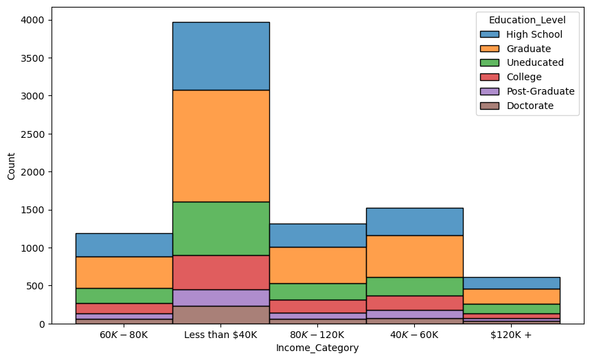

```python
plt.figure(figsize=(10,6))
sns.histplot(data=df3, x='Income_Category',hue='Education_Level',multiple="stack"); plt.show()
```

It seems that Graduate is the mode Education Level for every income category. Hence, we will impute null values with the mode.

```python
df3.loc[df3.Marital_Status.isnull(), :]
```

|  | Attrition_Flag | Customer_Age | Gender | Dependent_count | Education_Level | Marital_Status | Income_Category | Card_Category | Months_on_book | Total_Relationship_Count | Months_Inactive_12_mon | Contacts_Count_12_mon | Credit_Limit | Total_Revolving_Bal | Avg_Open_To_Buy | Total_Amt_Chng_Q4_Q1 | Total_Trans_Amt | Total_Trans_Ct | Total_Ct_Chng_Q4_Q1 | Avg_Utilization_Ratio |
| --- | --- | --- | --- | --- | --- | --- | --- | --- | --- | --- | --- | --- | --- | --- | --- | --- | --- | --- | --- | --- |
| 3 | 1 | 40 | F | 4 | High School | NaN | Less than $40K | Blue | 34 | 3 | 4 | 1 | 3313.0 | 2517 | 796.0 | 1.405 | 1171 | 20 | 2.333 | 0.760 |
| 7 | 1 | 32 | M | 0 | High School | NaN | $60K - $80K | Silver | 27 | 2 | 2 | 2 | 29081.0 | 1396 | 27685.0 | 2.204 | 1538 | 36 | 0.714 | 0.048 |
| 10 | 1 | 42 | M | 5 | Uneducated | NaN | $120K + | Blue | 31 | 5 | 3 | 2 | 6748.0 | 1467 | 5281.0 | 0.831 | 1201 | 42 | 0.680 | 0.217 |
| 13 | 1 | 35 | M | 3 | Graduate | NaN | $60K - $80K | Blue | 30 | 5 | 1 | 3 | 8547.0 | 1666 | 6881.0 | 1.163 | 1311 | 33 | 2.000 | 0.195 |
| 15 | 1 | 44 | M | 4 | NaN | NaN | $80K - $120K | Blue | 37 | 5 | 1 | 2 | 4234.0 | 972 | 3262.0 | 1.707 | 1348 | 27 | 1.700 | 0.230 |
| ... | ... | ... | ... | ... | ... | ... | ... | ... | ... | ... | ... | ... | ... | ... | ... | ... | ... | ... | ... | ... |
| 10070 | 1 | 47 | M | 3 | High School | NaN | $80K - $120K | Silver | 40 | 5 | 3 | 2 | 34516.0 | 1371 | 33145.0 | 0.691 | 15930 | 123 | 0.836 | 0.040 |
| 10100 | 1 | 39 | M | 2 | Graduate | NaN | $60K - $80K | Silver | 36 | 4 | 2 | 2 | 29808.0 | 0 | 29808.0 | 0.669 | 16098 | 128 | 0.684 | 0.000 |
| 10101 | 1 | 42 | M | 2 | Graduate | NaN | $40K - $60K | Blue | 30 | 3 | 2 | 5 | 3735.0 | 1723 | 2012.0 | 0.595 | 14501 | 92 | 0.840 | 0.461 |
| 10118 | 0 | 50 | M | 1 | NaN | NaN | $80K - $120K | Blue | 36 | 6 | 3 | 4 | 9959.0 | 952 | 9007.0 | 0.825 | 10310 | 63 | 1.100 | 0.096 |
| 10125 | 0 | 30 | M | 2 | Graduate | NaN | $40K - $60K | Blue | 36 | 4 | 3 | 3 | 5281.0 | 0 | 5281.0 | 0.535 | 8395 | 62 | 0.722 | 0.000 |

749 rows × 20 columns

For marital status, we shall also impute missing values with mode.

```python
imputer = SimpleImputer(strategy="most_frequent")
impute  = imputer.fit(X_train)

X_train[:] = impute.transform(X_train)
X_val[:]   = impute.transform(X_val)
X_test[:]  = impute.transform(X_test)
```

### Model Evaluation Criterion:

Two ways model can make wrong predictions:

- Predicting that a customer will become attrited when they actually stay (false negative).
- Predicting that a customer will stay when they actually attrite (false positive).

The second error is more cost-heavy for the bank because the bank's motive is to have a high customer retention. In other words, the bank seeks to identify the customers who will leave their credit card services and why. If the bank wrongly predicts customer attrition, they will lose the customer, and in turn, revenue for the company. Correctly predicting whether an existing customer will attrite will help the bank take possible steps to retain them.

This is a case of maximizing Precision or minimizing false positives.

Let's start by building different models using KFold and cross_val_score and tune the best model using GridSearchCV and RandomizedSearchCV.

```python
models = [
    ('logit',LogisticRegression(random_state=1)),
    ('dtree',DecisionTreeClassifier(random_state=1)),
    ('rf',RandomForestClassifier(random_state=1)),
    ('bagc',BaggingClassifier(random_state=1)),
    ('abc',AdaBoostClassifier(random_state=1)),
    ('gbc',GradientBoostingClassifier(random_state=1)),
    ('xgbc',XGBClassifier(random_state=1,eval_metric="logloss")),
]

results = []  # Empty list to store all model's CV scores
names   = []  # Empty list to store name of the models
scoring = 'precision'

# loop through all models to get the mean cross validated score
print("\n" "Cross-Validation Performance:" "\n")

for name, model in models:
    kfold = StratifiedKFold(
        n_splits=10, shuffle=True, random_state=1
    )  # Setting number of splits equal to 10

    cv_result = cross_val_score(
        estimator=model, X=X_train, y=y_train, scoring=scoring, cv=kfold
    )

    results.append(cv_result)
    names.append(name)
    print("{}: {}".format(name, cv_result.mean() * 100))

print("\n" "Training Performance:" "\n")

for name, model in models:
    model.fit(X_train, y_train)
    scores = metrics.precision_score(y_train, model.predict(X_train)) * 100
    print("{}: {}".format(name, scores))
```

```
Cross-Validation Performance:

logit: 90.426334685305
dtree: 96.17167748722494
rf: 96.18370677767358
bagc: 97.33406824576616
abc: 96.78109768296176
gbc: 97.30412469611049
xgbc: 97.75470885323308

Training Performance:

logit: 90.93057607090104
dtree: 100.0
rf: 100.0
bagc: 99.85886780617845
abc: 97.30948678071539
gbc: 98.00123954136969
xgbc: 100.0
```

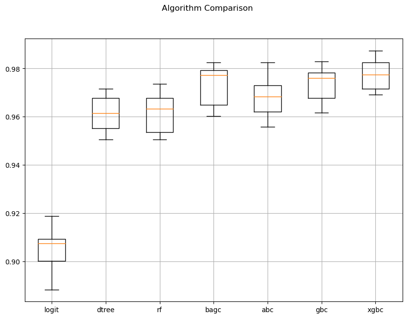

```python
# Plotting boxplots for CV scores of all models defined above
fig = plt.figure(figsize=(10, 7))

fig.suptitle("Algorithm Comparison")
ax = fig.add_subplot(111)

plt.boxplot(results)
ax.set_xticklabels(names)
plt.grid()
plt.show()
```

We can see that XGBoost, Bagging Classifier and Gradient Boost Classifier models perform the best. Let's build models with undersampled and oversampled data next.

### Oversampling

```python
# Fit SMOTE on train data(Synthetic Minority Oversampling Technique)
sm = SMOTE(sampling_strategy=0.6, k_neighbors=5, random_state=1)
X_train_over, y_train_over = sm.fit_resample(X_train, y_train)

print("Before OverSampling, count of label '1': {}".format(sum(y_train == 1)))
print("Before OverSampling, count of label '0': {} \n".format(sum(y_train == 0)))

print("After OverSampling, count of label '1': {}".format(sum(y_train_over == 1)))
print("After OverSampling, count of label '0': {} \n".format(sum(y_train_over == 0)))

print("After OverSampling, the shape of train_X: {}".format(X_train_over.shape))
print("After OverSampling, the shape of train_y: {} \n".format(y_train_over.shape))
```

```
Before OverSampling, count of label '1': 6375
Before OverSampling, count of label '0': 1220

After OverSampling, count of label '1': 6375
After OverSampling, count of label '0': 3825

After OverSampling, the shape of train_X: (10200, 29)
After OverSampling, the shape of train_y: (10200,)
```

```python
results_over = []  # Empty list to store all model's CV scores
names   = []  # Empty list to store name of the models
scoring = 'precision'

# loop through all models to get the mean cross validated score
print("\n" "Cross-Validation Performance:" "\n")

for name, model in models:
    kfold = StratifiedKFold(
        n_splits=10, shuffle=True, random_state=1
    )  # Setting number of splits equal to 10

    cv_result = cross_val_score(
        estimator=model, X=X_train_over, y=y_train_over, scoring=scoring, cv=kfold
    )

    results_over.append(cv_result)
    names.append(name)
    print("{}: {}".format(name, cv_result.mean() * 100))

print("\n" "Training Performance:" "\n")

for name, model in models:
    model.fit(X_train_over, y_train_over)
    scores_over = metrics.precision_score(y_train_over, model.predict(X_train_over)) * 100
    print("{}: {}".format(name, scores_over))
```

```
Cross-Validation Performance:

logit: 85.30360740358866
dtree: 96.19682918924318
rf: 97.61349720880906
bagc: 97.52648291536303
abc: 96.60509061597328
gbc: 97.40335793683983
xgbc: 98.26764447813893

Training Performance:

logit: 85.71872089413226
dtree: 100.0
rf: 100.0
bagc: 99.93711680553372
abc: 96.66875195495777
gbc: 97.99284269488096
xgbc: 100.0
```

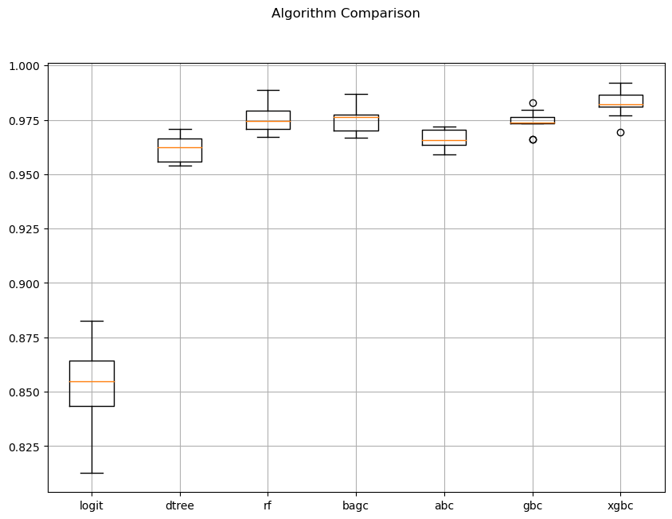

```python
# Plotting boxplots for CV scores of all models defined above
fig = plt.figure(figsize=(10, 7))

fig.suptitle("Algorithm Comparison")
ax = fig.add_subplot(111)

plt.boxplot(results_over)
ax.set_xticklabels(names)
plt.grid()
plt.show()
```

By oversampling the minority class (0) to 60\%, performance of various models changed. The performance of the Logit model decreased, but most other models' performance (precision scores) remained the same.

### Undersampling

```python
# fit random under sampler on the train data
rus = RandomUnderSampler(random_state=1, sampling_strategy = 1)
X_train_un, y_train_un = rus.fit_resample(X_train, y_train)

print("Before Under Sampling, count of label '1': {}".format(sum(y_train == 1)))
print("Before Under Sampling, count of label '0': {} \n".format(sum(y_train == 0)))

print("After Under Sampling, count of label '1': {}".format(sum(y_train_un == 1)))
print("After Under Sampling, count of label '0': {} \n".format(sum(y_train_un == 0)))

print("After Under Sampling, the shape of train_X: {}".format(X_train_un.shape))
print("After Under Sampling, the shape of train_y: {} \n".format(y_train_un.shape))
```

```
Before Under Sampling, count of label '1': 6375
Before Under Sampling, count of label '0': 1220

After Under Sampling, count of label '1': 1220
After Under Sampling, count of label '0': 1220

After Under Sampling, the shape of train_X: (2440, 29)
After Under Sampling, the shape of train_y: (2440,)
```

```python
results_un = []  # Empty list to store all model's CV scores
names   = []  # Empty list to store name of the models
scoring = 'precision'

# loop through all models to get the mean cross validated score
print("\n" "Cross-Validation Performance:" "\n")

for name, model in models:
    kfold = StratifiedKFold(
        n_splits=10, shuffle=True, random_state=1
    )  # Setting number of splits equal to 10

    cv_result = cross_val_score(
        estimator=model, X=X_train_un, y=y_train_un, scoring=scoring, cv=kfold
    )

    results_un.append(cv_result)
    names.append(name)
    print("{}: {}".format(name, cv_result.mean() * 100))

print("\n" "Training Performance:" "\n")

for name, model in models:
    model.fit(X_train_un, y_train_un)
    scores_un = metrics.precision_score(y_train_un, model.predict(X_train_un)) * 100
    print("{}: {}".format(name, scores_un))
```

```
Cross-Validation Performance:

logit: 79.43066067036236
dtree: 89.30113604762234
rf: 95.25864770906259
bagc: 94.68014478754752
abc: 93.94872166565979
gbc: 95.01691640888298
xgbc: 95.70893530411053

Training Performance:

logit: 82.22768222768224
dtree: 100.0
rf: 100.0
bagc: 99.58609271523179
abc: 95.68106312292359
gbc: 98.17427385892115
xgbc: 100.0
```

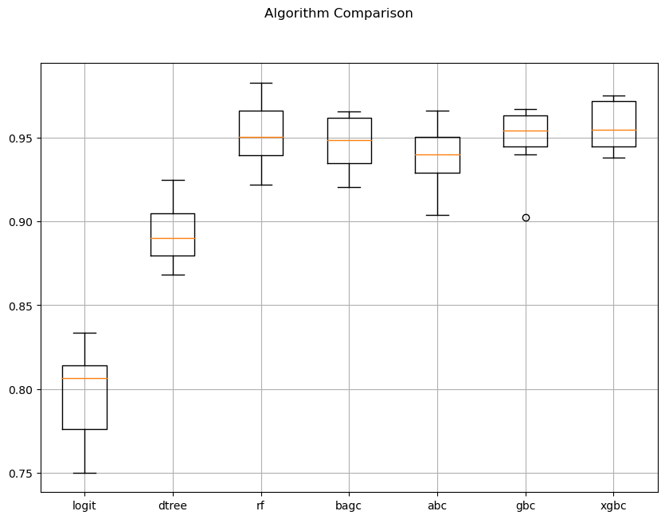

```python
# Plotting boxplots for CV scores of all models defined above
fig = plt.figure(figsize=(10, 7))

fig.suptitle("Algorithm Comparison")
ax = fig.add_subplot(111)

plt.boxplot(results_un)
ax.set_xticklabels(names)
plt.grid()
plt.show()
```

Undersampling the data resulted in decreased scores for all models. We will stick to oversampling the data and will now move on to tuning hyperparameters for XGBoost, Gradient Boost, and Bagging Classifier models.

```python
# defining a function to compute different metrics to check performance of a classification model built using sklearn
def model_performance_classification_sklearn(model, X_train, y_train, X_val, y_val):
    """
    Check classification model performance

    model: classifier
    predictors: independent variables
    target: dependent variable
    """

    # predicting using the independent variables - Train set
    tr_pred = model.predict(X_train)

    tr_acc = metrics.accuracy_score(y_train, tr_pred)  # to compute Accuracy
    tr_recall = metrics.recall_score(y_train, tr_pred)  # to compute Recall
    tr_precision = metrics.precision_score(y_train, tr_pred)  # to compute Precision
    tr_f1 = metrics.f1_score(y_train, tr_pred)  # to compute F1-score

    # predicting using the independent variables - Validation set
    val_pred = model.predict(X_val)

    val_acc = metrics.accuracy_score(y_val, val_pred)  # to compute Accuracy
    val_recall = metrics.recall_score(y_val, val_pred)  # to compute Recall
    val_precision = metrics.precision_score(y_val, val_pred)  # to compute Precision
    val_f1 = metrics.f1_score(y_val, val_pred)  # to compute F1-score

    # creating a dataframe of metrics
    df_perf = pd.DataFrame(
        {"Train Accuracy": tr_acc, "Train Recall": tr_recall, "Train Precision": tr_precision, "Train F1": tr_f1,\
        "Val Accuracy": val_acc, "Val Recall": val_recall, "Val Precision": val_precision, "Val F1": val_f1},
        index=[0],
    )

    return df_perf

def confusion_matrix_sklearn(model, X_train, y_train, X_val, y_val):
    """
    Plot confusion_matrix with percentages

    model: classifier
    predictors: independent variables
    target: dependent variable
    """
    tr_y_pred = model.predict(X_train)
    tr_cm = metrics.confusion_matrix(y_train, tr_y_pred)
    tr_labels = np.asarray(
        [
            ["{0:0.0f}".format(item) + "\n{0:.2%}".format(item / tr_cm.flatten().sum())]
            for item in tr_cm.flatten()
        ]
    ).reshape(2, 2)

    ts_y_pred = model.predict(X_val)
    ts_cm = metrics.confusion_matrix(y_val, ts_y_pred)
    ts_labels = np.asarray(
        [
            ["{0:0.0f}".format(item) + "\n{0:.2%}".format(item / ts_cm.flatten().sum())]
            for item in ts_cm.flatten()
        ]
    ).reshape(2, 2)

    fig, axes = plt.subplots(1, 2, figsize=(12,6))

    plt.subplot(1,2,1)
    sns.heatmap(tr_cm, annot=tr_labels, fmt="", ax=axes[0])
    plt.ylabel("True label")
    plt.xlabel("Predicted label")
    plt.title("Train Set")

    plt.subplot(1,2,2)
    sns.heatmap(ts_cm, annot=ts_labels, fmt="", ax=axes[1])
    plt.ylabel("True label")
    plt.xlabel("Predicted label")
    plt.title("Validation Set")
```

### XGBoost with Randmized Grid Search

```python
xgb = XGBClassifier(random_state=1,eval_metric='logloss')
xgb.fit(X_train, y_train)
xgb_perf = model_performance_classification_sklearn(xgb, X_train, y_train, X_val, y_val)
xgb_perf
```

|  | Train Accuracy | Train Recall | Train Precision | Train F1 | Val Accuracy | Val Recall | Val Precision | Val F1 |
| --- | --- | --- | --- | --- | --- | --- | --- | --- |
| 0 | 1.0 | 1.0 | 1.0 | 1.0 | 0.973476 | 0.988568 | 0.98 | 0.984265 |

```python
xgb_over = XGBClassifier(random_state=1,eval_metric='logloss')
xgb_over.fit(X_train_over, y_train_over)
xgb_over_perf = model_performance_classification_sklearn(xgb_over, X_train_over, y_train_over, X_val, y_val)
xgb_over_perf
```

|  | Train Accuracy | Train Recall | Train Precision | Train F1 | Val Accuracy | Val Recall | Val Precision | Val F1 |
| --- | --- | --- | --- | --- | --- | --- | --- | --- |
| 0 | 1.0 | 1.0 | 1.0 | 1.0 | 0.970655 | 0.98386 | 0.981221 | 0.982539 |

```python
xgb_best = XGBClassifier(random_state=1,eval_metric='logloss')

#Parameter grid to pass in GridSearchCV
params_grid={'n_estimators':np.arange(50,150,50),
            'scale_pos_weight':[2,5,10],
            'learning_rate':[0.01,0.1,0.2,0.05],
            'gamma':[0,1,3,5],
            'subsample':[0.8,0.9,1],
            'max_depth':np.arange(1,5,1),
            'reg_lambda':[5,10]}


# Type of scoring used to compare parameter combinations
scorer = metrics.make_scorer(metrics.precision_score)

#Calling GridSearchCV
grid_cv = RandomizedSearchCV(estimator=xgb_best,param_distributions=params_grid, n_iter=20, scoring=scorer, cv=5, n_jobs = -1, verbose= 2)

#Fitting parameters in GridSearchCV
grid_cv.fit(X_train,y_train)

print("Best parameters are {} with CV score={}:" .format(grid_cv.best_params_,grid_cv.best_score_))
```

```
Fitting 5 folds for each of 20 candidates, totalling 100 fits
Best parameters are {'subsample': 1, 'scale_pos_weight': 2, 'reg_lambda': 5, 'n_estimators': 50, 'max_depth': 4, 'learning_rate': 0.2, 'gamma': 5} with CV score=0.9636591777585591:
```

```python
# Lets build the best XGBoost model
xgb_best = XGBClassifier(random_state=1,eval_metric='logloss',
                        subsample=1, scale_pos_weight=2, reg_lambda=5,
                         n_estimators=50, max_depth=4, learning_rate=0.2, gamma=3)
xgb_best.fit(X_train, y_train)
```

```
XGBClassifier(base_score=0.5, booster='gbtree', callbacks=None,
              colsample_bylevel=1, colsample_bynode=1, colsample_bytree=1,
              early_stopping_rounds=None, enable_categorical=False,
              eval_metric='logloss', feature_types=None, gamma=3, gpu_id=-1,
              grow_policy='depthwise', importance_type=None,
              interaction_constraints='', learning_rate=0.2, max_bin=256,
              max_cat_threshold=64, max_cat_to_onehot=4, max_delta_step=0,
              max_depth=4, max_leaves=0, min_child_weight=1, missing=nan,
              monotone_constraints='()', n_estimators=50, n_jobs=0,
              num_parallel_tree=1, predictor='auto', random_state=1, ...)
```

```python
xgb_best_perf = model_performance_classification_sklearn(xgb_best, X_train, y_train, X_val, y_val)
xgb_best_perf
```

|  | Train Accuracy | Train Recall | Train Precision | Train F1 | Val Accuracy | Val Recall | Val Precision | Val F1 |
| --- | --- | --- | --- | --- | --- | --- | --- | --- |
| 0 | 0.976695 | 0.99702 | 0.975745 | 0.986267 | 0.96219 | 0.99462 | 0.961638 | 0.977851 |

```python
xgb_best_over = XGBClassifier(random_state=1,eval_metric='logloss')

#Parameter grid to pass in GridSearchCV
params_grid={'n_estimators':np.arange(50,150,50),
            'scale_pos_weight':[2,5,10],
            'learning_rate':[0.01,0.1,0.2,0.05],
            'gamma':[0,1,3,5],
            'subsample':[0.8,0.9,1],
            'max_depth':np.arange(1,5,1),
            'reg_lambda':[5,10]}


# Type of scoring used to compare parameter combinations
scorer = metrics.make_scorer(metrics.precision_score)

#Calling GridSearchCV
grid_cv = RandomizedSearchCV(estimator=xgb_best_over,param_distributions=params_grid, n_iter=20, scoring=scorer, cv=5, n_jobs = -1, verbose= 2)

#Fitting parameters in GridSearchCV
grid_cv.fit(X_train_over,y_train_over)

print("Best parameters are {} with CV score={}:" .format(grid_cv.best_params_,grid_cv.best_score_))
```

```
Fitting 5 folds for each of 20 candidates, totalling 100 fits
Best parameters are {'subsample': 1, 'scale_pos_weight': 5, 'reg_lambda': 5, 'n_estimators': 100, 'max_depth': 4, 'learning_rate': 0.2, 'gamma': 1} with CV score=0.9578872196307188:
```

```python
# Lets build the best XGBoost model
xgb_best_over = XGBClassifier(random_state=1,eval_metric='logloss',
                        subsample=0.8, scale_pos_weight=2, reg_lambda=10,
                         n_estimators=100, max_depth=3, learning_rate=0.2, gamma=0)
xgb_best_over.fit(X_train_over, y_train_over)
```

```
XGBClassifier(base_score=0.5, booster='gbtree', callbacks=None,
              colsample_bylevel=1, colsample_bynode=1, colsample_bytree=1,
              early_stopping_rounds=None, enable_categorical=False,
              eval_metric='logloss', feature_types=None, gamma=0, gpu_id=-1,
              grow_policy='depthwise', importance_type=None,
              interaction_constraints='', learning_rate=0.2, max_bin=256,
              max_cat_threshold=64, max_cat_to_onehot=4, max_delta_step=0,
              max_depth=3, max_leaves=0, min_child_weight=1, missing=nan,
              monotone_constraints='()', n_estimators=100, n_jobs=0,
              num_parallel_tree=1, predictor='auto', random_state=1, ...)
```

```python
xgb_best_over_perf = model_performance_classification_sklearn(xgb_best_over, X_train_over, y_train_over, X_val, y_val)
xgb_best_over_perf
```

|  | Train Accuracy | Train Recall | Train Precision | Train F1 | Val Accuracy | Val Recall | Val Precision | Val F1 |
| --- | --- | --- | --- | --- | --- | --- | --- | --- |
| 0 | 0.982059 | 0.99451 | 0.977189 | 0.985773 | 0.96614 | 0.989913 | 0.970336 | 0.980027 |

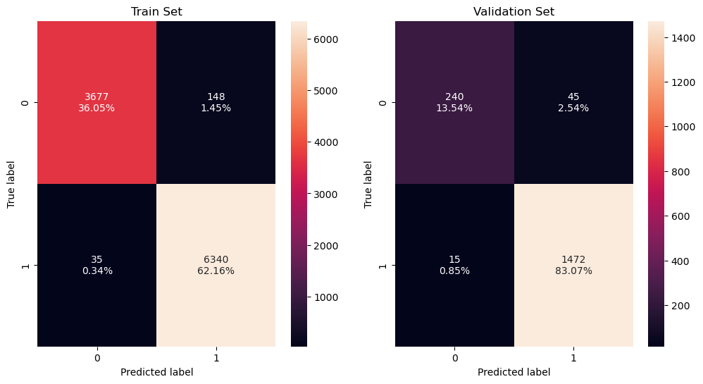

```python
confusion_matrix_sklearn(xgb_best_over, X_train_over, y_train_over, X_val, y_val)
```

```python
XGB_models_comp_df = pd.concat(
    [
        xgb_perf.T,
        xgb_over_perf.T,
        xgb_best_perf.T,
        xgb_best_over_perf.T,
    ],
    axis=1,
)
XGB_models_comp_df.columns = [
    "XGBoost",
    "XGBoost on Oversampled Data",
    "Xgboost Tuned with Random Search",
    "Xgboost Tuned with Random Search - Oversampled",
]
print("Training performance comparison:")
XGB_models_comp_df
```

```
Training performance comparison:
```

|  | XGBoost | XGBoost on Oversampled Data | Xgboost Tuned with Random Search | Xgboost Tuned with Random Search - Oversampled |
| --- | --- | --- | --- | --- |
| Train Accuracy | 1.000000 | 1.000000 | 0.976695 | 0.982059 |
| Train Recall | 1.000000 | 1.000000 | 0.997020 | 0.994510 |
| Train Precision | 1.000000 | 1.000000 | 0.975745 | 0.977189 |
| Train F1 | 1.000000 | 1.000000 | 0.986267 | 0.985773 |
| Val Accuracy | 0.973476 | 0.970655 | 0.962190 | 0.966140 |
| Val Recall | 0.988568 | 0.983860 | 0.994620 | 0.989913 |
| Val Precision | 0.980000 | 0.981221 | 0.961638 | 0.970336 |
| Val F1 | 0.984265 | 0.982539 | 0.977851 | 0.980027 |

Out of all four of the above models, best precision is of the XGBoost model trained on oversampled data, without hypertuning parameters. However, this might be overfitting since the parameters on the training data are all 1.0.

In this case, we would prefer XGBoost tuned on oversampled data, which has a precision score of 97\%, and is not overfitting the data. Let's see its performance on the test data.

```python
# defining a function to compute different metrics to check performance of a classification model built using sklearn
def model_performance_classification_sklearn_test(model, predictors, target):
    """
    Function to compute different metrics to check classification model performance

    model: classifier
    predictors: independent variables
    target: dependent variable
    """

    # predicting using the independent variables
    pred = model.predict(predictors)

    acc = metrics.accuracy_score(target, pred)  # to compute Accuracy
    recall = metrics.recall_score(target, pred)  # to compute Recall
    precision = metrics.precision_score(target, pred)  # to compute Precision
    f1 = metrics.f1_score(target, pred)  # to compute F1-score

    # creating a dataframe of metrics
    df_perf = pd.DataFrame(
        {"Accuracy": acc, "Recall": recall, "Precision": precision, "F1": f1,},
        index=[0],
    )

    return df_perf

def confusion_matrix_sklearn_test(model, predictors, target):
    """
    To plot the confusion_matrix with percentages

    model: classifier
    predictors: independent variables
    target: dependent variable
    """
    y_pred = model.predict(predictors)
    cm = metrics.confusion_matrix(target, y_pred)
    labels = np.asarray(
        [
            ["{0:0.0f}".format(item) + "\n{0:.2%}".format(item / cm.flatten().sum())]
            for item in cm.flatten()
        ]
    ).reshape(2, 2)

    plt.figure(figsize=(6, 4))
    sns.heatmap(cm, annot=labels, fmt="")
    plt.ylabel("True label")
    plt.xlabel("Predicted label")
```

```python
xgb_best_over_test_perf = model_performance_classification_sklearn_test(xgb_best_over, X_test, y_test)
xgb_best_over_test_perf
```

|  | Accuracy | Recall | Precision | F1 |
| --- | --- | --- | --- | --- |
| 0 | 0.969737 | 0.992163 | 0.97235 | 0.982157 |

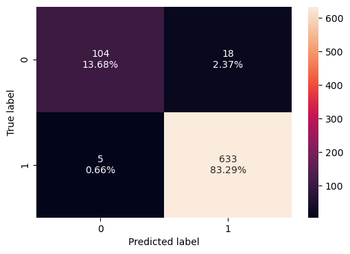

```python
confusion_matrix_sklearn_test(xgb_best_over, X_test, y_test)
```

### Bagging Classifier

For all upcoming models, we will only train them on oversampled data.

```python
bagc_over = BaggingClassifier(random_state=1)
bagc_over.fit(X_train_over, y_train_over)
```

```
BaggingClassifier(random_state=1)
```

```python
bagc_over_perf_train = model_performance_classification_sklearn(bagc_over, X_train_over, y_train_over, X_val, y_val)
bagc_over_perf_train
```

|  | Train Accuracy | Train Recall | Train Precision | Train F1 | Val Accuracy | Val Recall | Val Precision | Val F1 |
| --- | --- | --- | --- | --- | --- | --- | --- | --- |
| 0 | 0.997843 | 0.997176 | 0.999371 | 0.998273 | 0.954289 | 0.969065 | 0.976287 | 0.972663 |

```python
bagc_best_over = BaggingClassifier(random_state=1)

# Grid of parameters to choose from
params_grid = {'max_samples': [0.7,0.8,0.9,1],
              'max_features': [0.7,0.8,0.9,1],
              'n_estimators' : [10,20,30,40,50],
             }


# Type of scoring used to compare parameter combinations
scorer = metrics.make_scorer(metrics.precision_score)

#Calling GridSearchCV
grid_cv = RandomizedSearchCV(estimator=bagc_best_over,param_distributions=params_grid, n_iter=20, scoring=scorer, cv=5, n_jobs = -1, verbose= 2)

#Fitting parameters in GridSearchCV
grid_cv.fit(X_train_over,y_train_over)

print("Best parameters are {} with CV score={}:" .format(grid_cv.best_params_,grid_cv.best_score_))
```

```
Fitting 5 folds for each of 20 candidates, totalling 100 fits
Best parameters are {'n_estimators': 10, 'max_samples': 0.9, 'max_features': 0.7} with CV score=0.9801547567502723:
```

```python
bagc_best_over = BaggingClassifier(
random_state=1, n_estimators=30, max_samples=0.9, max_features=0.7
)
bagc_best_over.fit(X_train_over, y_train_over)
```

```
BaggingClassifier(max_features=0.7, max_samples=0.9, n_estimators=30,
                  random_state=1)
```

```python
bagc_best_over_perf_train = model_performance_classification_sklearn(bagc_best_over, X_train_over, y_train_over, X_val, y_val)
bagc_best_over_perf_train
```

|  | Train Accuracy | Train Recall | Train Precision | Train F1 | Val Accuracy | Val Recall | Val Precision | Val F1 |
| --- | --- | --- | --- | --- | --- | --- | --- | --- |
| 0 | 1.0 | 1.0 | 1.0 | 1.0 | 0.965576 | 0.982515 | 0.976604 | 0.979551 |

```python
bagc_best_over_perf_test = model_performance_classification_sklearn_test(bagc_best_over, X_test, y_test)
bagc_best_over_perf_test
```

|  | Accuracy | Recall | Precision | F1 |
| --- | --- | --- | --- | --- |
| 0 | 0.953947 | 0.973354 | 0.971831 | 0.972592 |

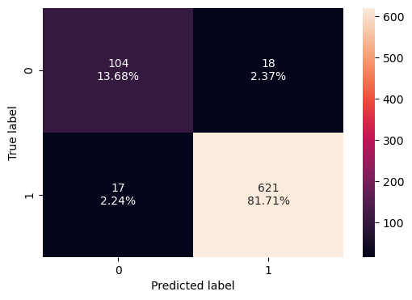

```python
confusion_matrix_sklearn_test(bagc_best_over, X_test, y_test)
```

### Gradient Boost Classifier

```python
gbc_over = GradientBoostingClassifier(random_state=1)
gbc_over.fit(X_train_over, y_train_over)
```

```
GradientBoostingClassifier(random_state=1)
```

```python
gbc_over_perf_train = model_performance_classification_sklearn(gbc_over, X_train_over, y_train_over, X_val, y_val)
gbc_over_perf_train
```

|  | Train Accuracy | Train Recall | Train Precision | Train F1 | Val Accuracy | Val Recall | Val Precision | Val F1 |
| --- | --- | --- | --- | --- | --- | --- | --- | --- |
| 0 | 0.979804 | 0.987922 | 0.979928 | 0.983909 | 0.967269 | 0.984533 | 0.976651 | 0.980576 |

```python
gbc_best = GradientBoostingClassifier(random_state=1)

# Grid of parameters to choose from
params_grid = {
    "n_estimators": [100,150,200,250],
    "subsample":[0.8,0.9,1],
    "max_features":[0.7,0.8,0.9,1]
}

# Type of scoring used to compare parameter combinations
scorer = metrics.make_scorer(metrics.precision_score)

#Calling GridSearchCV
grid_cv = RandomizedSearchCV(estimator=gbc_best,param_distributions=params_grid, n_iter=20, scoring=scorer, cv=5, n_jobs = -1, verbose= 2)

#Fitting parameters in GridSearchCV
grid_cv.fit(X_train_over,y_train_over)

print("Best parameters are {} with CV score={}:" .format(grid_cv.best_params_,grid_cv.best_score_))
```

```
Fitting 5 folds for each of 20 candidates, totalling 100 fits
Best parameters are {'subsample': 0.9, 'n_estimators': 250, 'max_features': 0.9} with CV score=0.9764677997796394:
```

```python
gbc_best_over = GradientBoostingClassifier(
random_state=1, n_estimators=250, subsample=0.9, max_features=0.7
)
gbc_best_over.fit(X_train_over, y_train_over)
```

```
GradientBoostingClassifier(max_features=0.7, n_estimators=250, random_state=1,
                           subsample=0.9)
```

```python
gbc_best_over_perf_train = model_performance_classification_sklearn(gbc_best_over, X_train_over, y_train_over, X_val, y_val)
gbc_best_over_perf_train
```

|  | Train Accuracy | Train Recall | Train Precision | Train F1 | Val Accuracy | Val Recall | Val Precision | Val F1 |
| --- | --- | --- | --- | --- | --- | --- | --- | --- |
| 0 | 0.991078 | 0.994667 | 0.991091 | 0.992876 | 0.974041 | 0.987223 | 0.98194 | 0.984574 |

```python
gbc_best_over_perf_test = model_performance_classification_sklearn_test(gbc_best_over, X_test, y_test)
gbc_best_over_perf_test
```

|  | Accuracy | Recall | Precision | F1 |
| --- | --- | --- | --- | --- |
| 0 | 0.969737 | 0.990596 | 0.973806 | 0.982129 |

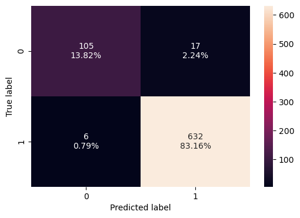

```python
confusion_matrix_sklearn_test(gbc_best_over, X_test, y_test)
```

```python
# Test performance comparison

best_models_comp_df = pd.concat(
    [
        xgb_best_over_test_perf.T,
        bagc_best_over_perf_test.T,
        gbc_best_over_perf_test.T
    ],
    axis=1,
)

best_models_comp_df.columns = [
    "XGBoost RandomSearch Oversampled - Test",
    "Bagging Classifier RandomSearch Oversampled - Test",
    "Gradient Boost RandomSearch Oversampled - Test",
]

print("Training performance comparison:")
best_models_comp_df
```

```
Training performance comparison:
```

|  | XGBoost RandomSearch Oversampled - Test | Bagging Classifier RandomSearch Oversampled - Test | Gradient Boost RandomSearch Oversampled - Test |
| --- | --- | --- | --- |
| Accuracy | 0.969737 | 0.953947 | 0.969737 |
| Recall | 0.992163 | 0.973354 | 0.990596 |
| Precision | 0.972350 | 0.971831 | 0.973806 |
| F1 | 0.982157 | 0.972592 | 0.982129 |

Observations:

- Of all three models, the tuned Gradient Boost Classifier model on oversampled training data had the highest Precision score of 97.3\%, closely followed by XGBoost and then Bagging Classifier.
- XGBoost and Gradient Boost had similar F1, Recall and Accuracy scores, all slightly more than Bagging Classifier

We will now construct the production ML model pipeline using Gradient Boost Classifier with the tuned parameters on oversampled training data.

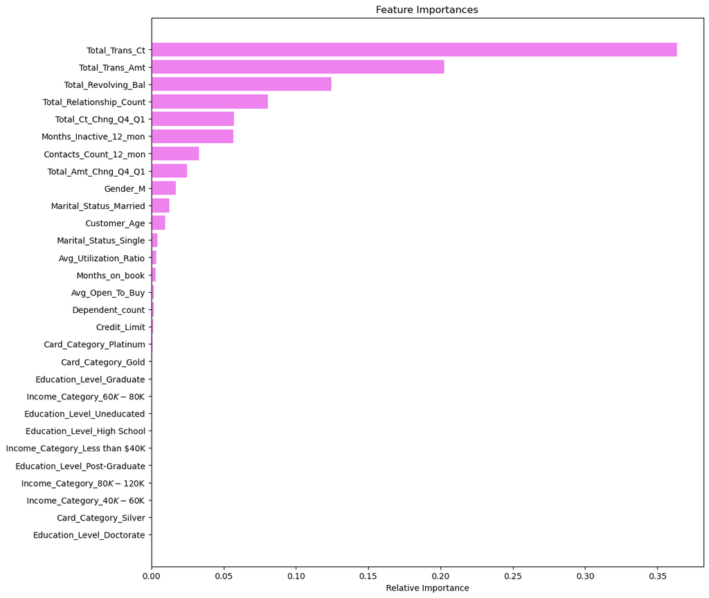

```python
feature_names = X.columns
importances = gbc_best_over.feature_importances_
indices = np.argsort(importances)

plt.figure(figsize=(12, 12))
plt.title("Feature Importances")
plt.barh(range(len(indices)), importances[indices], color="violet", align="center")
plt.yticks(range(len(indices)), [feature_names[i] for i in indices])
plt.xlabel("Relative Importance")
plt.show()
```

Observations:

- A customer's total transaction count was the most important feature in the Gradient Boosting model, which is intuitively obvious - the more transactions a customer has had in the last 12 months, the more it is indicative that they are liking the product and intend to continue using it.
- The total transaction amount was the second most important, for similar reasons perhaps - the more amount of money a customer has spent in the last 12 months, the more likely they are to continue doing so with the same product. They may be accruing various incentives such as points, etc on their credit card, which Thera Bank might offer through their products, this incentivizing customers to stay.
- Total revolving balance, surprisingly, is the third most important feature.
- Total Relationship count (number of products held by customer) is the fourth most important feature. This is important to note because this is a lever the bank can use for customers predicted to be attrited by the model, so that they can be retained. Similar reasoning can be employed for number of inactive months and contacts count in the last 12 months - Thera Bank can influence these numbers to retain customers who would otherwise attrite.

## Pipeline for Productionizing Model

We will employ Column Transfer to transform numerical columns separately from categorical columns. Numerical columns had missing null values, which categorical columns might also have in the unseen data. However, categorical columns's missing values will be mode or "most_frequent", whereas numerical columns' missing values will be median (skewed data). Categorical columns will also require onehot encoding/dummy creation.

```python
numerical_cols
```

```
Index(['Customer_Age', 'Dependent_count', 'Months_on_book',
       'Total_Relationship_Count', 'Months_Inactive_12_mon',
       'Contacts_Count_12_mon', 'Credit_Limit', 'Total_Revolving_Bal',
       'Avg_Open_To_Buy', 'Total_Amt_Chng_Q4_Q1', 'Total_Trans_Amt',
       'Total_Trans_Ct', 'Total_Ct_Chng_Q4_Q1', 'Avg_Utilization_Ratio'],
      dtype='object')
```

```python
categorical_cols
```

```
Index(['Attrition_Flag', 'Gender', 'Education_Level', 'Marital_Status',
       'Income_Category', 'Card_Category'],
      dtype='object')
```

```python
categorical_cols = [col for col in categorical_cols if col != 'Attrition_Flag']
print(categorical_cols)
```

```
['Gender', 'Education_Level', 'Marital_Status', 'Income_Category', 'Card_Category']
```

```python
numeric_transformer = Pipeline(
    steps= [
        ("imputer", SimpleImputer(strategy='median'))
    ]
)

categorical_transformer = Pipeline(
    steps = [
        ("imputer", SimpleImputer(strategy="most_frequent")),
        ("onehot", OneHotEncoder(handle_unknown = 'ignore'))
    ]
    # handle_unknown = "ignore", allows model to handle any unknown category in the test data
)

# combine both transformers
preprocessor = ColumnTransformer(
    transformers = [
            ("num", numeric_transformer, numerical_cols),
            ("cat", categorical_transformer, categorical_cols),
    ],
    remainder="passthrough",
)
# remainder = "passthrough" has been used, it will allow variables that are present in original data
# but not in "numerical_columns" and "categorical_columns" to pass through the column transformer without any changes
```

```python
# Separating target variable and other variables
X = df3.drop(columns="Attrition_Flag")
y = df3["Attrition_Flag"]

# Splitting the data into train and test sets - we know the best model so we don't need validation set anymore
X_train, X_test, y_train, y_test = train_test_split(
    X, y, test_size=0.30, random_state=1, stratify=y
)
print(X_train.shape, X_test.shape, y_train.shape, y_test.shape)
```

```
(7088, 19) (3039, 19) (7088,) (3039,)
```

```python
# Creating new pipeline with best parameters
pipe_model = Pipeline(
    steps=[
        ("pre", preprocessor),
        (
            "GBC",
            GradientBoostingClassifier(
                random_state=1,
                n_estimators=250,
                subsample=0.9,
                max_features=0.7
            )
        )
    ]
)
# Fit the model on training data
pipe_model.fit(X_train, y_train)
```

```
Pipeline(steps=[('pre',
                 ColumnTransformer(remainder='passthrough',
                                   transformers=[('num',
                                                  Pipeline(steps=[('imputer',
                                                                   SimpleImputer(strategy='median'))]),
                                                  Index(['Customer_Age', 'Dependent_count', 'Months_on_book',
       'Total_Relationship_Count', 'Months_Inactive_12_mon',
       'Contacts_Count_12_mon', 'Credit_Limit', 'Total_Revolving_Bal',
       'Avg_Open_To_Buy', 'Total_Amt_Ch...
       'Total_Trans_Ct', 'Total_Ct_Chng_Q4_Q1', 'Avg_Utilization_Ratio'],
      dtype='object')),
                                                 ('cat',
                                                  Pipeline(steps=[('imputer',
                                                                   SimpleImputer(strategy='most_frequent')),
                                                                  ('onehot',
                                                                   OneHotEncoder(handle_unknown='ignore'))]),
                                                  ['Gender', 'Education_Level',
                                                   'Marital_Status',
                                                   'Income_Category',
                                                   'Card_Category'])])),
                ('GBC',
                 GradientBoostingClassifier(max_features=0.7, n_estimators=250,
                                            random_state=1, subsample=0.9))])
```

```python
# transforming and predicting on test data
pipe_model.predict(X_test)
```

```
array([1, 1, 1, ..., 0, 1, 0])
```

## Business Recommendations

- Customers attrite because largely because they are not using the product enough. Thera Bank can perhaps provide incentives for using their credit card(s) to those customers who have been inactive for more months in the last year, and/or who's spending activity has been decreasing. Some incentives include giving cash back offers, less interest, no late fees, etc.
- Customers who hold more products are more likely to stay as existing customers. The bank may market other products to those customers who hold only one or two products so they can take advantage of more services offered by the bank, and hence be less likely to attrite.